# Lab 4

## Step 1

Import data and assign the data to a variable.

```r
if (!file.exists("met_all.gz"))
  download.file(
    url = "https://raw.githubusercontent.com/USCbiostats/data-science-data/master/02_met/met_all.gz",
    destfile = "met_all.gz",
    method   = "libcurl",
    timeout  = 60
    )
met_all <- read.csv("~/PM 556/PM556-/Lab 4/met_all.gz")
met <- met_all
```

## Step 2

Prepare Data

```r
# Make sure there is no missing data in the key variables coded as 9999
met$elev[met$elev==9999.0] <- NA
summary(met$elev)
```

```
   Min. 1st Qu.  Median    Mean 3rd Qu.    Max.     NAs
    -13     101     252     413     400    4113     710
```

```r
#Remove temperatures less than -17C
met <- met[met$temp > -17, ]
met2 <- met[order(met$temp), ]
head(met2)
```

```
        USAFID  WBAN year month day hour min    lat      lon elev wind.dir
2370758 726764 94163 2019     8  27   11  50 44.683 -111.116 2025       NA
2370759 726764 94163 2019     8  27   12  10 44.683 -111.116 2025       NA
2370760 726764 94163 2019     8  27   12  30 44.683 -111.116 2025       NA
2370761 726764 94163 2019     8  27   12  50 44.683 -111.116 2025       NA
252489  720411   137 2019     8  18   12  35 36.422 -105.290 2554       NA
2370688 726764 94163 2019     8  26   12  30 44.683 -111.116 2025       NA
        wind.dir.qc wind.type.code wind.sp wind.sp.qc ceiling.ht ceiling.ht.qc
2370758           9              C       0          5      22000             5
2370759           9              C       0          5      22000             5
2370760           9              C       0          5      22000             5
2370761           9              C       0          5      22000             5
252489            9              C       0          5      22000             5
2370688           9              C       0          5      22000             5
        ceiling.ht.method sky.cond vis.dist vis.dist.qc vis.var vis.var.qc temp
2370758                 9        N    16093           5       N          5 -3.0
2370759                 9        N    16093           5       N          5 -3.0
2370760                 9        N    16093           5       N          5 -3.0
2370761                 9        N    16093           5       N          5 -3.0
252489                  9        N    16093           5       N          5 -2.4
2370688                 9        N    16093           5       N          5 -2.0
        temp.qc dew.point dew.point.qc atm.press atm.press.qc       rh
2370758       C      -5.0            C        NA            9 86.26537
2370759       5      -4.0            5        NA            9 92.91083
2370760       5      -4.0            5        NA            9 92.91083
2370761       C      -4.0            C        NA            9 92.91083
252489        5      -3.7            5        NA            9 90.91475
2370688       5      -3.0            5        NA            9 92.96690
```

```r
# Generate a date variable using the functions as.Date()
met$Date <- as.Date(paste(met$year, met$month, met$day, sep = "-"))

# Subset the data to keep only the observations from the first week (7 days) of the month.
met <- subset(met, day <= 7)

# Compute the mean by station of the variables temp, rh, wind.sp, vis.dist, dew.point, lat, lon, and elev.
library(tidyverse)
met_avg <- summarize(met,
                     temp =     mean(temp, na.rm = TRUE),
                     rh =       mean(rh, na.rm = TRUE),
                     wind.sp =  mean(wind.sp, na.rm = TRUE),
                     vis.dist = mean(vis.dist, na.rm = TRUE),
                     dew.point = mean(dew.point, na.rm = TRUE),
                     lat =      mean(lat, na.rm = TRUE),
                     lon =      mean(lon, na.rm = TRUE),
                     elev =     mean(elev, na.rm = TRUE),
                     .by = c(USAFID))

# Create a region variable for NW, SW, NE, SE based on lon = -98 and lat = 39.71 degrees
met_avg$region <- with(met_avg,
                       ifelse(lon < -98 & lat >= 39.71, "NW",
                       ifelse(lon < -98 & lat <  39.71, "SW",
                       ifelse(lon >= -98 & lat >= 39.71, "NE", "SE"))))

#
met_avg$elev_cat <- ifelse(met_avg$elev > 252, "high", "low")
```

## Step 3

Use geom_violin to examine the relative humidity and dew point by region.

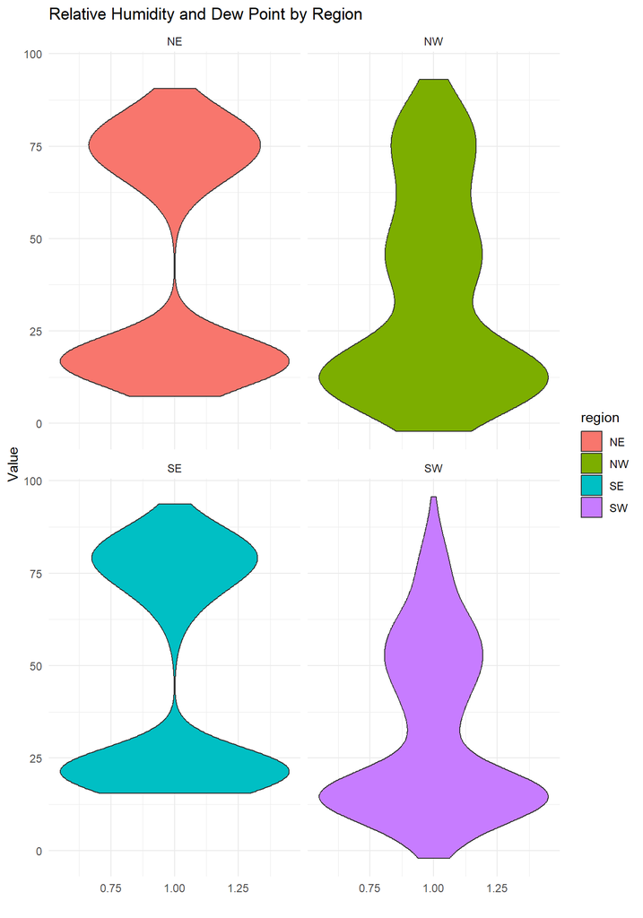

```r
library(tidyverse)

met_long <- met_avg %>%
  select(region, rh, dew.point) %>%
  pivot_longer(
    cols = c(rh, dew.point),
    names_to = "variable",
    values_to = "value"
  ) %>%
  drop_na()

ggplot(met_long, aes(x = 1, y = value, fill = region)) +
  geom_violin() +
  facet_wrap(~ region) +
  labs(
    title = "Relative Humidity and Dew Point by Region",
    x = "",
    y = "Value"
  ) +
  theme_minimal()
```

## Step 4

Use geom_point with stat_smooth to examine the association between dew point and relative humidity by region.

Describe what you observe in the graph. - There is a positive association between dew point and relative humidity across all regions. Regions differ slightly in slope and spread, but in general, higher dew point corresponds to higher RH. Some regions show tighter clustering (more consistent conditions), while others show more variability.

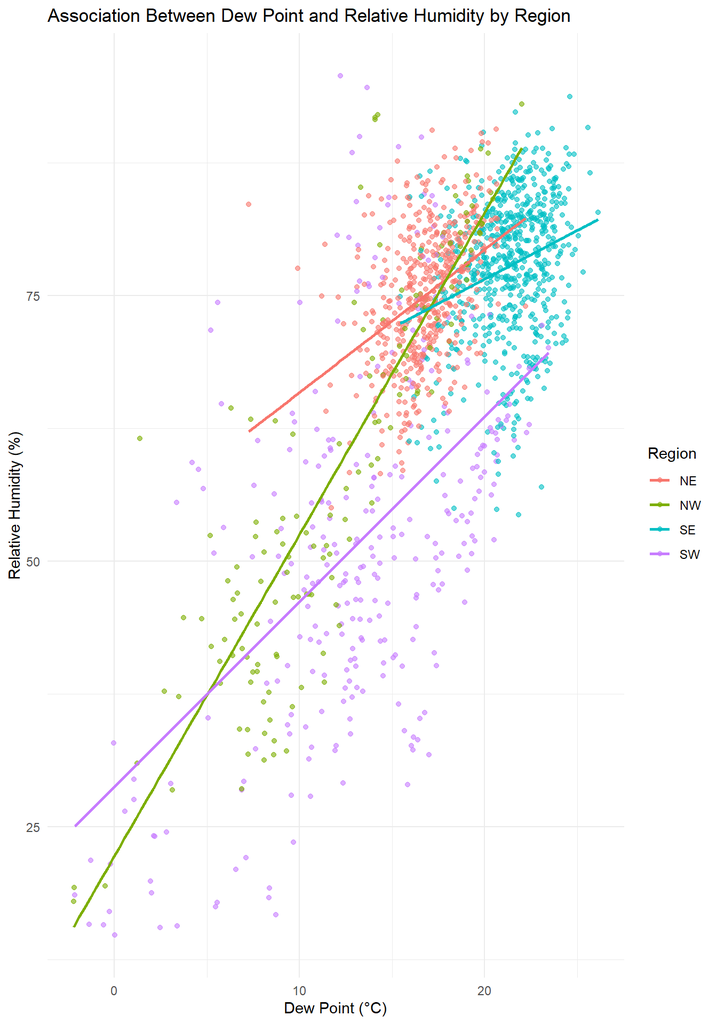

```r
ggplot(met_avg, aes(x = dew.point, y = rh, color = region)) +
  geom_point(alpha = 0.6) +
  stat_smooth(method = "lm", se = FALSE) +
  labs(
    title = "Association Between Dew Point and Relative Humidity by Region",
    x = "Dew Point (°C)",
    y = "Relative Humidity (%)",
    color = "Region"
  ) +
  theme_minimal()
```

## Step 5

Use geom_bar to create barplots of the weather stations by elevation category colored by region. - Bars by elevation category using position=“dodge” - Change colors from the default. Color by region using scale_fill_brewer see this. -Create nice labels on the axes and add a title.

[output not shown]

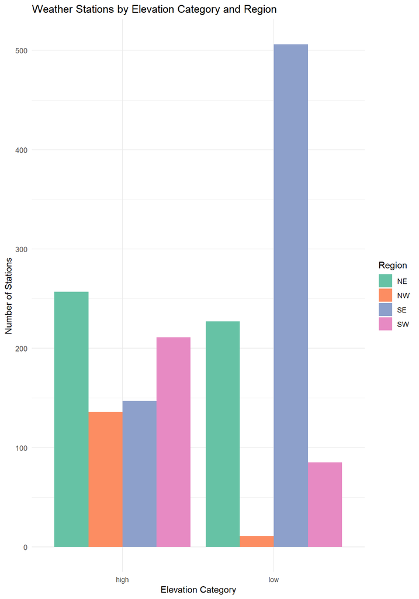

```r
# Create barplots of the weather stations by elevation category colored by region
ggplot(met_avg, aes(x = elev_cat, fill = region)) +
  geom_bar(position = "dodge") +
  scale_fill_brewer(palette = "Set2") +
  labs(
    title = "Weather Stations by Elevation Category and Region",
    x = "Elevation Category",
    y = "Number of Stations",
    fill = "Region"
  ) +
  theme_minimal()
```

## Step 6

Use stat_summary to examine mean dew point and wind speed by region with standard deviation error bar - Use fun.data=“mean_sdl” in stat_summary - Add another layer of stats_summary but change the geom to “errorbar”

Describe the graph and what you observe. - Dew point varies by region. Some regions show higher mean dew point values, indicating more moisture in the air, while others have lower averages. The error bars show that variability differs across regions.

```
- Wind speed also differs by region. Certain regions have higher average wind speeds, while others are calmer speeds. The standard deviation bars reveals how variable wind conditions are within each region.
```

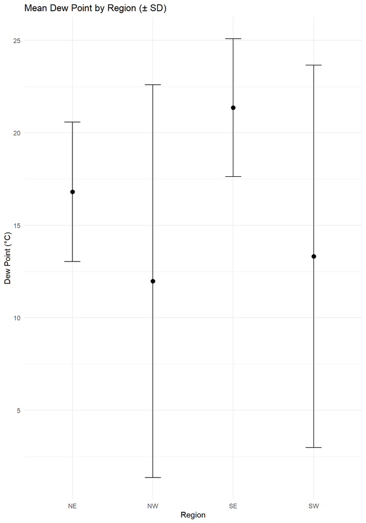

```r
# Dew Point by Region
ggplot(met_avg, aes(x = region, y = dew.point)) +
  stat_summary(fun.data = "mean_sdl", geom = "pointrange") +
  stat_summary(fun.data = "mean_sdl", geom = "errorbar", width = 0.2) +
  labs(
    title = "Mean Dew Point by Region (± SD)",
    x = "Region",
    y = "Dew Point (°C)"
  ) +
  theme_minimal()
```

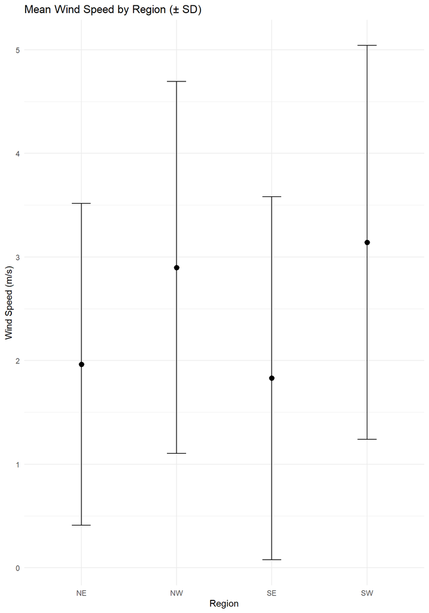

```r
# Wind Speed by Region
ggplot(met_avg, aes(x = region, y = wind.sp)) +
  stat_summary(fun.data = "mean_sdl", geom = "pointrange") +
  stat_summary(fun.data = "mean_sdl", geom = "errorbar", width = 0.2) +
  labs(
    title = "Mean Wind Speed by Region (± SD)",
    x = "Region",
    y = "Wind Speed (m/s)"
  ) +
  theme_minimal()
```

## Step 7

Make a map showing the spatial trend in relative humidity in the US. - Use leaflet() or ggplot2 - Make a color palette with custom colors - Use addMarkers or geom_point to include the top 10 places in relative humidity (hint: this will be useful rank(-rh) <= 10) - Add a legend

Describe the trend in RH across the US. - The map shows spatial patterns in relative humidity across the United States. Higher RH values tend to cluster in specific regions, while other areas show consistently lower humidity. The top 10 stations (highlighted in red) indicate where moisture levels are highest.

```r
met_top10 <- met_avg %>%
  mutate(rank_rh = rank(-rh, ties.method = "first")) %>%
  filter(rank_rh <= 10)

#
library(leaflet)

pal <- colorNumeric(
  palette = c("lightblue", "blue", "darkblue"),
  domain  = met_avg$rh
)

leaflet(met_avg) %>%
  addTiles() %>%
  addCircleMarkers(
    ~lon, ~lat,
    color = ~pal(rh),
    radius = 4,
    stroke = FALSE,
    fillOpacity = 1,
    popup = ~paste0("Station: ", USAFID, "<br>RH: ", round(rh, 1), "%")
  ) %>%
  addCircleMarkers(
    data = met_top10,
    ~lon, ~lat,
    color = "red",
    radius = 6,
    stroke = TRUE,
    weight = 2,
    fillOpacity = 1,
    popup = ~paste0("TOP RH Station: ", USAFID, "<br>RH: ", round(rh, 1), "%")
  ) %>%
  addLegend(
    "bottomright",
    pal    = pal,
    values = ~rh,
    title  = "Relative Humidity (%)"
  )
```

[interactive chart not shown]

## Step 8

Use a ggplot extension. Pick an extension (except cowplot) from here and make a plot of your choice using the met_avg. - I decided to pick gganimate to display the met_avg data.

[output not shown]

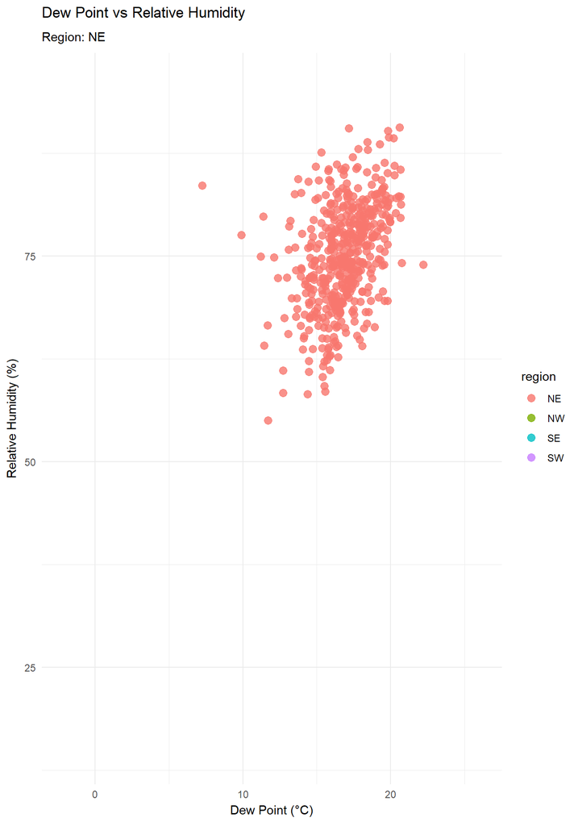

```r
# run these packages.
library(tidyverse)
library(gganimate)
library(magick)   # ⭐ REQUIRED
p <- ggplot(met_avg, aes(x = dew.point, y = rh, color = region)) +
  geom_point(size = 3, alpha = 0.8) +
  labs(
    title = "Dew Point vs Relative Humidity",
    subtitle = "Region: {closest_state}",
    x = "Dew Point (°C)",
    y = "Relative Humidity (%)"
  ) +
  theme_minimal() +
  transition_states(region, transition_length = 2, state_length = 1) +
  ease_aes("linear")

# ⭐ REQUIRED FOR QUARTO + MAGICK
print(animate(p, nframes = 120, fps = 10, renderer = magick_renderer()))
```